# SIT 112 - Data Science Concepts - Assignment 1

## **Instruction 5**

**Your tasks**:

1. Define a function called **compute_time_day_year** that takes Year, Crash_Month, Crash_Day and Crash_Time as the inputs and returns day of week (Monday, Tuesday, Wednesday, Thursday, Friday, Saturday, Sunday), time of the day (Morning - 06:00-11:59, Afternoon - 12:00-17:59, Evening - 18:00-23:59, Night - 00:00 - 05:59), and season of the year (Winter for June, July and August; Spring for September, October, November; Summer for December, January, February; Autumn for March, April, May). If either of the input parameters is in incorrect form, the function returns `INVALID` in all outputs. (**4 marks**)
2. Write your code to calculate an array containing the day of week, the time of the day and the season of the year for all accident records. Print the first 10 entries in the array. (**2 marks**)
3. Construct a new array called **valid_DTS_list** to store only valid entries and then print out the number of elements in the array. (**3 marks**)
4. Compute the accident numbers for each of the days of week in the dataset and plot them as a bar chart. Also, print minimum, maximum, mean and median of the computed accident numbers. (**1 mark**)
5. Compute the accident numbers for each of the seasons (Summer, Autumn, Winter, Spring) in the dataset and plot them as a bar chart. (**1 mark**)
6. Compute the accident numbers with Injury_Severity equal to 1 for each of the times of the day (Morning, Afternoon, Evening, Night) in the dataset and plot them as a bar chart. (**1 mark**)
7. Why is the median of the accident numbers integer and the mean is not? Write a brief answer. (**3 marks**)

[**Total mark: 15**]

```python
def computeTimeDayYear(year, month, day, time):
    intMonth = int(month)
    intDay = int(day)
    strTime = ''

    x = True
    count = 0
    while x:
        if time[count] == ':':
            x = False
        elif time[count] in ['0','1','2','3','4','5','6','7','8','9']:
            strTime = strTime + time[count]
            count += 1
        else:
            return 'INVALID','INVALID1','INVALID'
    intTime = int(strTime)

    days = ['Monday',
            'Tuesday',
            'Wednesday',
            'Thursday',
            'Friday',
            'Saturday',
            'Sunday']

    if intMonth in [12,1,2]:
        endSeason = 'Summer'
    elif intMonth in [3,4,5]:
        endSeason = 'Autumn'
    elif intMonth in [6,7,8]:
        endSeason = 'Winter'
    elif intMonth in [9,10,11]:
        endSeason = 'Spring'
    else:
        return 'INVALID','INVALID2','INVALID'

    if intDay in range(1,8):
        endDay = days[intDay - 1]
    else:
        return 'INVALID','INVALID3','INVALID'

    if intTime in [6,7,8,9,10,11]:
        endTime = 'Morning'
    elif intTime in [12,13,14,15,16,17]:
        endTime = 'Afternoon'
    elif intTime in [18,19,20,21,22,23]:
        endTime = 'Evening'
    elif intTime in [0,1,2,3,4,5]:
        endTime = 'Night'
    else:
        return 'INVALID','INVALID4','INVALID'

    return endDay, endTime, endSeason


print(computeTimeDayYear('2019', '12', '7', '12:30:59'))
```

```
('Sunday', 'Afternoon', 'Summer')
```

```python
def listTimes(data_dict):
    listOfTimes = []
    for i in range(0, len(data_dict['Index'])):
        try:
            listOfTimes.append(computeTimeDayYear(data_dict['Year'][i],
                               data_dict['Crash_Month'][i],
                               data_dict['Crash_Day'][i],
                               data_dict['Crash_Time'][i]))
        except:
            break
    return listOfTimes

def printX(inList, x):
    for i in range(x):
        print(inList[i])

printX(listTimes(data_dict), 10)
```

```
('Monday', 'Night', 'Summer')
('Monday', 'Night', 'Summer')
('Monday', 'Night', 'Summer')
('Monday', 'Night', 'Summer')
('Monday', 'Night', 'Summer')
('Monday', 'Night', 'Summer')
('Monday', 'Night', 'Summer')
('Monday', 'Night', 'Summer')
('Monday', 'Night', 'Summer')
('Monday', 'Night', 'Summer')
```

```python
def checkValidity(inList):
    validList = []
    invalidIndexList = []
    invalidReasonList = []
    for i in range(len(inList)):
        if inList[i][0] != 'INVALID':
            validList.append(inList[i])
        else:
            invalidIndexList.append(i)
            invalidReasonList.append(inList[i][1])
    return validList, invalidIndexList, invalidReasonList

print(len(checkValidity(listTimes(data_dict))[0]))
```

```
111056
```

```
15865.142857142857
1659.6665266226937
17379
(18572, 'Sunday')
(13865, 'Tuesday')
```

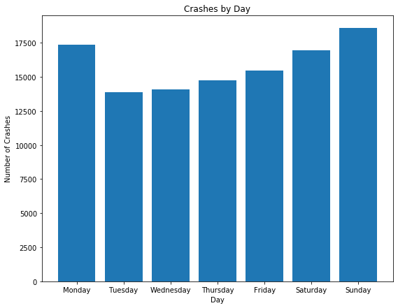

```python
def takeIndexFromSubList(listOfLists, index):
    outList = []
    for i in listOfLists:
        outList.append(i[index])
    return outList

def convertDictToLists(inDict):
    keyList = []
    varList = []
    for i in inDict:
        keyList.append(i)
        varList.append(inDict[i])
    return keyList, varList

def calcDictMean(data):
    countDict = countObjects(data)
    keyList, varList = convertDictToLists(countDict)
    mean = calcMean(varList)
    return mean

def calcDictStdDev(data):
    countDict = countObjects(data)
    keyList, varList = convertDictToLists(countDict)
    StdDev = calcStdDev(varList)
    return StdDev

def calcDictMedian(data):
    countDict = countObjects(data)
    keyList, varList = convertDictToLists(countDict)
    Median = calcMedian(varList)
    return Median

def findDictMax(data, keys):
    countDict = countObjects(data)
    keyList, varList = convertDictToLists(countDict)
    Max, index = findMax(varList)
    key = keys[index]
    return Max, key

def findDictMin(data, keys):
    countDict = countObjects(data)
    keyList, varList = convertDictToLists(countDict)
    Min, index = findMin(varList)
    key = keys[index]
    return Min, key


print(calcDictMean(takeIndexFromSubList(checkValidity(listTimes(data_dict))[0], 0)))
print(calcDictStdDev(takeIndexFromSubList(checkValidity(listTimes(data_dict))[0], 0)))
print(calcDictMedian(takeIndexFromSubList(checkValidity(listTimes(data_dict))[0], 0)))

days = ['Monday',
        'Tuesday',
        'Wednesday',
        'Thursday',
        'Friday',
        'Saturday',
        'Sunday']

print(findDictMax(takeIndexFromSubList(checkValidity(listTimes(data_dict))[0], 0), days))
print(findDictMin(takeIndexFromSubList(checkValidity(listTimes(data_dict))[0], 0), days))

displayBarChartOfCounts(takeIndexFromSubList(checkValidity(listTimes(data_dict))[0], 0),
                        "Crashes by Day",
                        "Day",
                        "Number of Crashes")
```

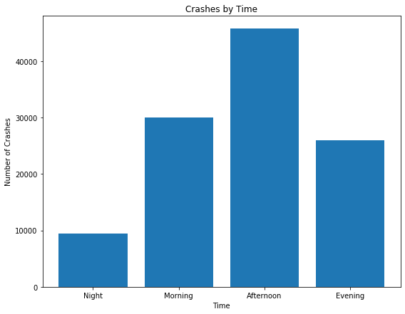

```python
displayBarChartOfCounts(takeIndexFromSubList(checkValidity(listTimes(data_dict))[0], 1),
                        "Crashes by Time",
                        "Time",
                        "Number of Crashes")
```

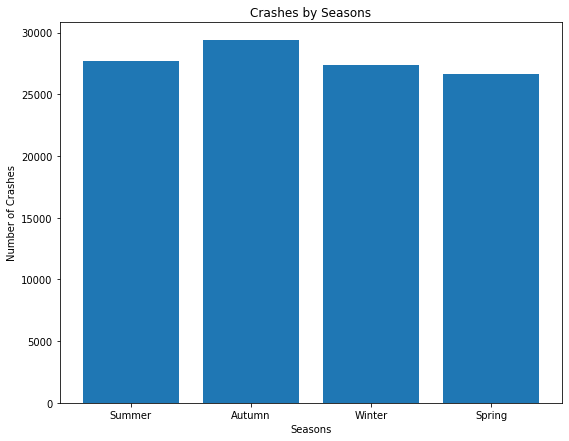

```python
displayBarChartOfCounts(takeIndexFromSubList(checkValidity(listTimes(data_dict))[0], 2),
                        "Crashes by Seasons",
                        "Seasons",
                        "Number of Crashes")
```

```python
# Why is the median of the accident numbers integer and the mean is not? Write a brief answer.

# the median of a set of numbers is the middle value in the set and in a set of integers it will always be an integer
# the mean is calculated as the sum of all items in the set divided by the number of items in the set and isn't always an integer even if it comes from a set of integers
```

## **Instruction 6**

Continue from the previous steps, **your tasks are:**

1. Write your code to find and print all the invalid entry indices. An entry is invalid if it has been marked as `INVALID` by **compute_time_day_year** function. Also print how many invalid entries are in the dataset. (**2 marks**)
2. Write your code to filter out all invalid entries and store your data into a new variable **data_dict_cleaned** and print out the number of data records after being cleaned. (**2 marks**)
3. Define a function, which takes a time string in form `%H:%M:%S` as an input and computes time in hours since midnight. Note that the time in hours does not have to be integer. (**3 marks**)
4. Write your code to produce a scatter plot of age of a person involved in a car accident vs time since midnight for that accident. Use the data for year 2005 only. (**3 marks**)

[**Total mark: 10**]

```python
def printTableIndecies(inList):
    for i in inList:
        print(data_dict['Index'][i],
              data_dict['Age'][i],
              data_dict['Year'][i],
              data_dict['Crash_Month'][i],
              data_dict['Crash_Day'][i],
              data_dict['Crash_Time'][i],
              data_dict['Road_User'][i],
              data_dict['Gender'][i],
              data_dict['Crash_Type'][i],
              data_dict['Injury_Severity'][i],
              data_dict['Crash_LGA'][i],
              data_dict['Crash_Area_Type'][i])

invalidList, invalidReasonList = checkValidity(listTimes(data_dict))[1:]

print(len(invalidList))
printTableIndecies(invalidList)
```

[output not shown]

[output cut: 4471 more lines]

```python
def cleanData(data_dict, invalidList):
    columns = {'Index',
               'Age',
               'Year',
               'Crash_Month',
               'Crash_Day',
               'Crash_Time',
               'Road_User',
               'Gender',
               'Crash_Type',
               'Injury_Severity',
               'Crash_LGA',
               'Crash_Area_Type'}
    itemsDict = {}
    for i in columns:
        itemsDict[i] = []
    for i in range(len(data_dict['Index'])):
        if not(i in invalidList):
            itemsDict['Index'].append(data_dict['Index'][i])
            itemsDict['Age'].append(data_dict['Age'][i])
            itemsDict['Year'].append(data_dict['Year'][i])
            itemsDict['Crash_Month'].append(data_dict['Crash_Month'][i])
            itemsDict['Crash_Day'].append(data_dict['Crash_Day'][i])
            itemsDict['Crash_Time'].append(data_dict['Crash_Time'][i])
            itemsDict['Road_User'].append(data_dict['Road_User'][i])
            itemsDict['Gender'].append(data_dict['Gender'][i])
            itemsDict['Crash_Type'].append(data_dict['Crash_Type'][i])
            itemsDict['Injury_Severity'].append(data_dict['Injury_Severity'][i])
            itemsDict['Crash_LGA'].append(data_dict['Crash_LGA'][i])
            itemsDict['Crash_Area_Type'].append(data_dict['Crash_Area_Type'][i])
    return itemsDict

data_dict_cleaned = cleanData(data_dict, invalidList)
print(len(data_dict_cleaned['Index']))
```

```
111056
```

```python
def strToTime(inStr):
    time = inStr.split(':')
    hour = int(time[0])
    minute = int(time[1])
    second = int(time[2])
    outTime = [hour, minute, second]
    return outTime

def hoursSinceMidnight(inTime):
    hoursPast = inTime[2] * 0.0002777777777778
    hoursPast += inTime[1] * 0.01666666666667
    hoursPast += inTime[0]
    return hoursPast

print(hoursSinceMidnight(strToTime('0:48:16')))
```

```
0.8044444444446048
```

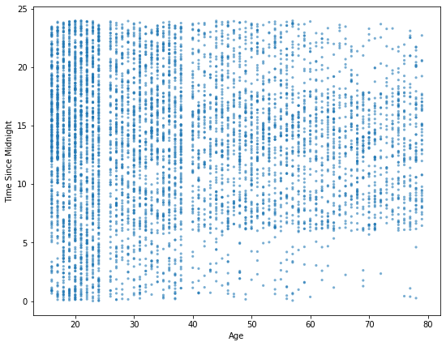

```python
def findValuesOfIndexInColumn(data_dict, indexList, column):
    outList = []
    for i in indexList:
        outList.append(data_dict[column][i])
    return outList

crash2005 = findIndexOf(data_dict_cleaned, 'Year', 2005)


rawTimes = findValuesOfIndexInColumn(data_dict_cleaned, crash2005, 'Crash_Time')
times = []
for i in rawTimes:
    times.append(hoursSinceMidnight(strToTime(i)))


rawAges = findValuesOfIndexInColumn(data_dict_cleaned, crash2005, 'Age')
ages = []
for i in rawAges:
    ages.append(int(i))


fig, ax = plt.subplots(figsize=(9, 7))
ax.scatter(ages, times, alpha=0.6, edgecolor='none', s=10)
ax.set_xlabel('Age')
ax.set_ylabel('Time Since Midnight')
```

## **Instruction 7**

Think about the results above. Can you tell which fields in the dataset have been tampered with? Why do you think so? (**5 marks**)

[**Total mark: 5**]

```python
# The ages of around 25 and 39 have probably been tampered with.
# I think this as there seems to have been no crashes by people
# of that age which is bizzare as people of those ages are rather
# likely to crash
```